# Problem Set 4

## Objectives

- Students will demonstrate familiarity with how to write basic functions
- Students will practice making simple maps in R and uploading them to Rpubs
- Students will be able to assess powerpoint in light of the “Cognitive Style of Powerpoint”
- Students will practice using list_columns and map_* in functions

For this problem set, we’re going to use the American Community Survey. From [this](https://walkerke.github.io/tidycensus/articles/basic-usage.html) very helpful website about tidycensus: “American Community Survey data differ from decennial Census data in that ACS data are based on an annual sample of approximately 3 million households, rather than a more complete enumeration of the US population. In turn, ACS data points are estimates characterized by a margin of error. Tidycensus will always return the estimate and margin of error together for any requested variables.”

Use the `get_acs` command in tidycensus to get data at the country level for the year 2018. The variable you’ll need is “B19013_001”, or median household income.

### Mad Libs

For Mad libs 1-3, we’ll give you the code for a simple function. Each function has one simple error. Once you debug the error, you should use the function to solve the mad lib. You only need to make one change to each chunk of code to get it to run. Hint: when debugging code, it’s often easiest to start by running the code for yourself and seeing what error message you get.

The first function calculates standard deviation of a variable, plus one.

```r
# This function should take a numeric vector (like our column, estimate) and
# calculate the standard deviation of the variable, then adds 1.

sd_plus_one <- function(var, na.rm = TRUE){
  x<- sd(var, na.rm = na.rm + 1)
  return(x
  }

sd_plus_one(var = income$estimate)
```

**ML 1)** (Note that for all the madlibs you *must* call the function to receive points for this question: you cannot just manually calculate the mad lib result.) The standard deviation of median income, plus one, is X.

The second function uses stringr to return just the state for a county, state, evaluation.

```r
# This function should take a county and state pair and extracts just the state
# name. We can do this easily because the state name is always after a comma and
# space.

 get_state <- function(countystate){
  countystate
  str_split_fixed(.,", ", 2) %>%
  pluck(2) %>%
  return()
 }

get_state("Treasure County, Montana")
```

**ML 2)** Treasure County, Montana is located in the state of X.

The third function calculates the upper bound of the income variable, using the margin of error.

```r
# This function should take the geoid for a given county, grabs the median income for the
# corresponding county, and then add the margin of error to the value.

upper_bound <- function(x){
 income %>%
 filter(GEOID == geoid) %>%
 mutate(estimate + moe) %>%
 pull())
}

upper_bound(geoid = "01005")
```

## Question 2: Mapping

We are going to make a map of median income using the ACS data. This mapping exercise is very similar to the one in PPBDS. Let’s use just the data from California. Replicate the map below (you may want to check out the `scales` package to help you label the legend.) If you get stuck, check out [the example](https://davidkane9.github.io/PPBDS/B-maps.html) in PPBDS

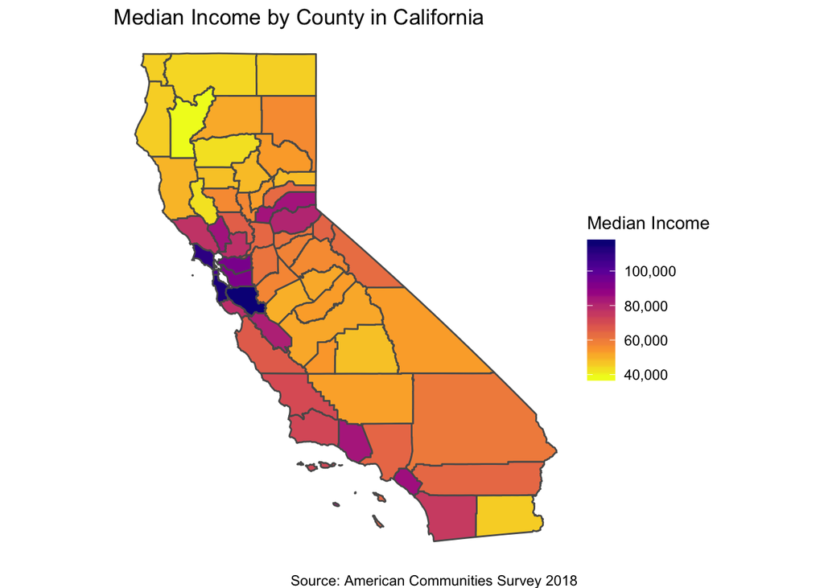

## Question 3: Publishing to Rpubs

Take your graphic from question 2 and publish it on Rpubs. Provide a link to it here.

Note that this requires a bit of care. (And, indeed, learning about this stuff is the real purpose of this question.) You can’t, for example, just hit the “publish” button on your ps_4.html. That will include not just your graphic but everything else from this problem set. You want just the graphic, as with [my Rpubs animation](http://rpubs.com/dkane/gganimate).

How to do that? There are many ways. Our advice: Get everything working as normal within ps_4.Rmd, including Q2. Once it looks perfect, create a new file, something like ps_4_rpub.Rmd. (We only require the existence of ps_4.Rmd and ps_4.html. There will often be occasions, like this one, when having other files is useful.) Copy the code you need for the graphic to ps_4_rpub.Rmd. (You might also make the YAML header cleaner (i.e., emptier) so that it does not add an unnecessary author/title/date to your graphic. Note how “clean” my animation looks.) Knit ps_4_rpub.Rmd to ps_4_rpub.html, hit the publish button, and copy the link for the resulting graphic as an answer to this question.

## Question 4: Understanding Tufte Reading

Write a short paragraph (max 250 words – parsimony is a virtue!) critiquing the `california_tax` Powerpoint included in this directory, using the Tufte reading as your guide. Be sure to provide thoughts on the **numeric content** of the visuals, the **role of logos**, and the **bullet structure** of the information. Give at least one suggestion of how some information in the Powerpoint could be better transmitted in an 8 x 11 handout.

## Question 5: Writing a functon

For question 5, we’re going to walk you through an exercise to get you comfortable with list columns. Whenever you feel confused, we recommend checking out [this](https://davidkane9.github.io/PPBDS/6-functions.html#practice-with-map_-functions-and-list-columns) example in *PPBDS*.

Note that whenever we use sample, you may get a different answer than your friends here (because of the random generator.) Sometimes when we want our work to be replicable, we’ll use `set.seed`. Other times, when we’re taking measures where the law of large numbers apply, we’ll do enough simulations so that we don’t need to worry about this. In this case, when we ask you for a number, just report what you got.

### 5A

In our example, we’re going to imagine that instead of using a numeric die, we’re using an alphabet die, which has every letter of the alphabet on it. Write a function called `get_dice` that rolls an alphabetical die n times and takes the earliest letter in the alphabet. **Hint**: typing the command `letters` will print all the letters in the english language for you. R also recognizes alphabetical order, so you can call min and max on characters. Print a call to your function with n = 3.

### 5C

Imagine that the Tf’s (Alyssa, Kaneesha, Mitchell and June) are playing a game where they each roll for three letters. Make a tibble that stores the results of them playing this game 100 times. Make a gt table showing the first 5 rows.

Each row of your gtable should have four letters. Let’s imagine that the first letter in each row is the letter that Alyssa rolled. Using the same scenario of 100 rolls and 4 tfs rolling 3 dice, use a `map_lgl` command to create a column “vowel”, which tests whether the first letter of each row is a vowel (a,e,i,o,u). Report how many times the letter selected was a vowel.

For example, we had `28` vowels.

### 5D

How surprised would you be if for all four tf’s the earliest alphabetical letter they rolled was a vowel? Using a tibble that shows the four tf’s playing the game 10,000 times, calculate the probability that they all roll a vowel.

### 5E

Using your functions, make a simple plot mapping the distribution of “first” letters in 1000 rolls of 3 dice. For this example, you can use a single “tf” (n = 1) when you call `roll_alpha_dice`. Hint: You might want to check out what `unnest` does.

### 5F

Finally, make a plot comparing 5E (selecting the earliest alphabetical letter from 3 dice) with an exercise where the first letter is selected from 5 dice. How does the distribution shift?